# Module 53

#### Contrast SVE:

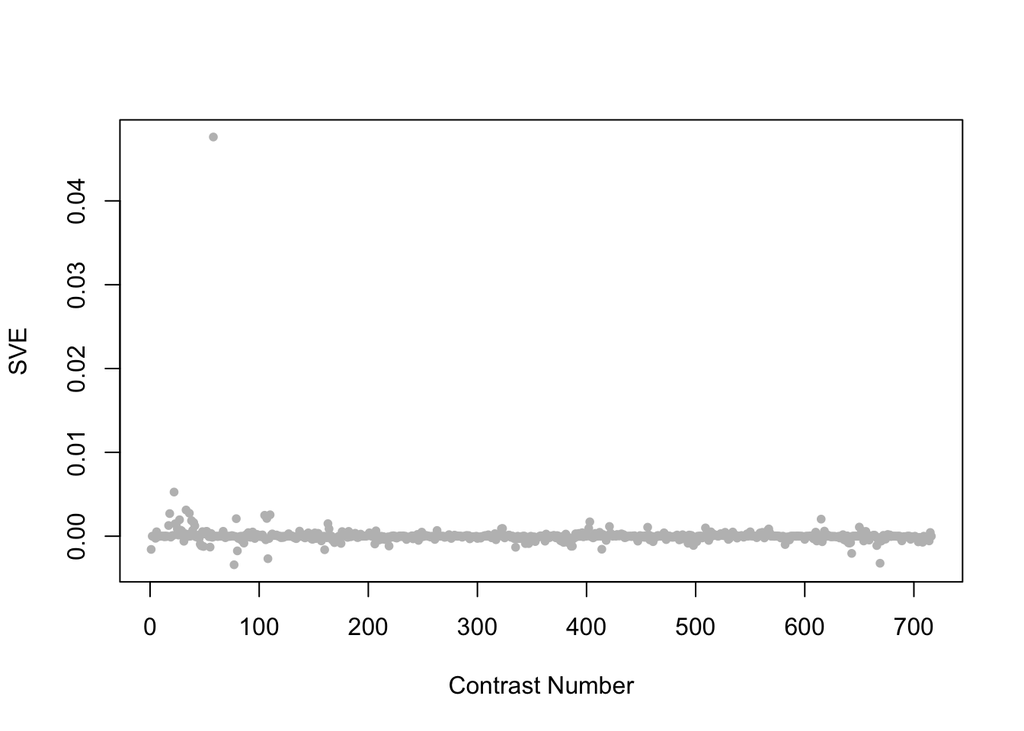

Positive SVE Contrasts:

|  | Contrast.Num | SVE | GEO.GSE | Cond.1 | Cond.2 | Mutation |
| --- | --- | --- | --- | --- | --- | --- |
| GSE9485.s2t1.vs.s1t1 | 58 | 0.05 | GSE9485 | Larval Reference, biological rep 1 | Larval Pan-neural, biological rep 1 |  |
| GSE9665.s1t2.vs.s0t2 | 22 | 0.01 | GSE9665 | mex-3 elt-1 186 A | mex-3 186 A | elt-1 |
| GSE9665.s12t2.vs.s0t2 | 33 | 0.00 | GSE9665 | mex-3 vab-7 186 A | mex-3 186 A | vab-7 |
| GSE9665.s5t3.vs.s0t3 | 36 | 0.00 | GSE9665 | mex-3 lin-26 230 A | mex-3 230 A | lin-26 |
| GSE9665.s4t1.vs.s0t1 | 18 | 0.00 | GSE9665 | mex-3 hnd-1 143 A | mex-3 143 A | hnd-1 |

Negative SVE Contrasts:

|  | Contrast.Num | SVE | GEO.GSE | Cond.1 | Cond.2 | Mutation |
| --- | --- | --- | --- | --- | --- | --- |
| GSE8004.s3t2.vs.s1t2 | 77 | -0.00 | GSE8004 | Larval Pan-neural, biological rep 1 of set 2 | Larval A-class, biological rep 1 of set 3 |  |
| GSE15016.s3t1.vs.s0t1 | 669 | -0.00 | GSE15016 | young adult_24hr DEHP exposure_rep1 | young adult_not exposured_rep1 |  |
| GSE54513.s3t1.vs.s2t1 | 108 | -0.00 | GSE54513 | spe-9 input rep1 | fog-1 OMA-1 IP rep1 |  |
| GSE16975.s1t1.vs.s0t1 | 643 | -0.00 | GSE16975 | C.elegans hydrogen sulfide sample replicate 1 | C.elegans control sample replicate 1 |  |
| GSE8004.s3t2.vs.s3t1 | 80 | -0.00 | GSE8004 | Larval Pan-neural, biological rep 1 of set 2 | Embryonic Pan-neural, biological rep 1 of set 1 |  |

$~$

#### Contrast SVE, Up-Regulated Genes Only:

Calculating SVE for up-regulated and down-regulated genes separately may be more informative in many cases than projecting the up- and down- gene sets together. This is due to the fact that the weight distribution of many modules is highly skewed, indicating that only one of the hemi-modules may be biologically meaningful (i.e., a set of genes are strongly correlated by only a few genes (or none) are strongly anti-correlated to that set.)

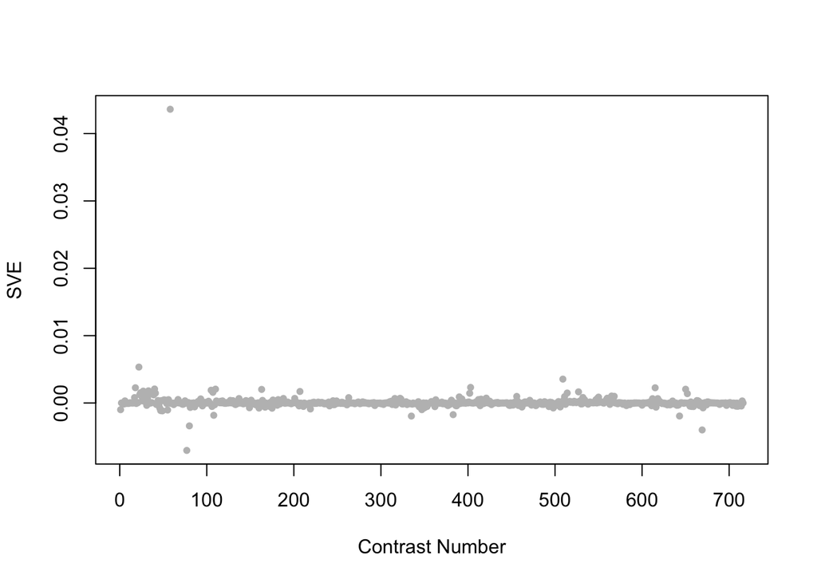

Positive SVE Contrasts:

|  | Contrast.Num | SVE | GEO.GSE | Cond.1 | Cond.2 | Mutation |
| --- | --- | --- | --- | --- | --- | --- |
| GSE9485.s2t1.vs.s1t1 | 58 | 0.04 | GSE9485 | Larval Reference, biological rep 1 | Larval Pan-neural, biological rep 1 |  |
| GSE9665.s1t2.vs.s0t2 | 22 | 0.01 | GSE9665 | mex-3 elt-1 186 A | mex-3 186 A | elt-1 |
| GSE2180.s2t1.vs.s1t1 | 509 | 0.00 | GSE2180 | ms0-1 | 00B | mex-3(zu155);skn-1(RNAi) |
| GSE30505.s3t1.vs.s4t1 | 403 | 0.00 | GSE30505 | L3 glp-1 E.V. #1 | L3 glp-1 ash-2 #1 | ash-2 |
| GSE9665.s4t1.vs.s0t1 | 18 | 0.00 | GSE9665 | mex-3 hnd-1 143 A | mex-3 143 A | hnd-1 |

Negative SVE Contrasts:

|  | Contrast.Num | SVE | GEO.GSE | Cond.1 | Cond.2 | Mutation |
| --- | --- | --- | --- | --- | --- | --- |
| GSE8004.s3t2.vs.s1t2 | 77 | -0.01 | GSE8004 | Larval Pan-neural, biological rep 1 of set 2 | Larval A-class, biological rep 1 of set 3 |  |
| GSE15016.s3t1.vs.s0t1 | 669 | -0.00 | GSE15016 | young adult_24hr DEHP exposure_rep1 | young adult_not exposured_rep1 |  |
| GSE8004.s3t2.vs.s3t1 | 80 | -0.00 | GSE8004 | Larval Pan-neural, biological rep 1 of set 2 | Embryonic Pan-neural, biological rep 1 of set 1 |  |
| GSE38997.s3t2.vs.s2t2 | 335 | -0.00 | GSE38997 | experiment 4 UVC- and EtBr-exposed samples at 24 h 4eu24 | experiment 4 EtBr-exposed samples at 24 h 4e24 |  |
| GSE16975.s1t1.vs.s0t1 | 643 | -0.00 | GSE16975 | C.elegans hydrogen sulfide sample replicate 1 | C.elegans control sample replicate 1 |  |

$~$

#### Contrast SVE, Down-Regulated Genes Only:

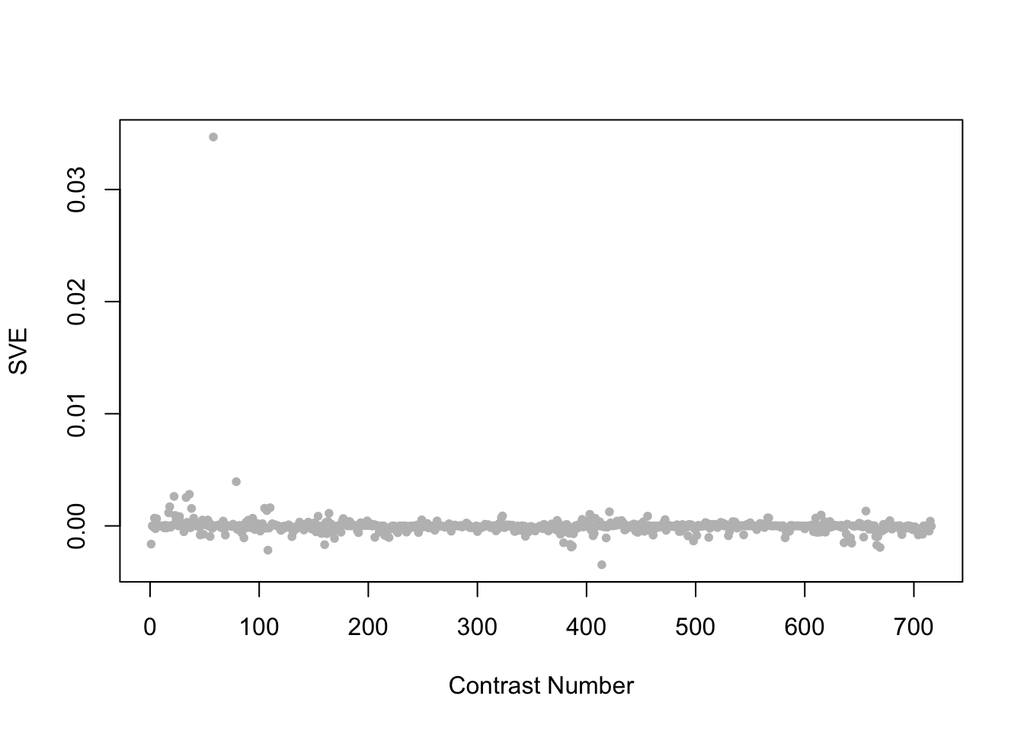

Positive SVE Contrasts:

|  | Contrast.Num | SVE | GEO.GSE | Cond.1 | Cond.2 | Mutation |
| --- | --- | --- | --- | --- | --- | --- |
| GSE9485.s2t1.vs.s1t1 | 58 | 0.03 | GSE9485 | Larval Reference, biological rep 1 | Larval Pan-neural, biological rep 1 |  |
| GSE8004.s2t2.vs.s3t2 | 79 | 0.00 | GSE8004 | Larval Reference, biological rep 1 of set 1 | Larval Pan-neural, biological rep 1 of set 2 |  |
| GSE9665.s5t3.vs.s0t3 | 36 | 0.00 | GSE9665 | mex-3 lin-26 230 A | mex-3 230 A | lin-26 |
| GSE9665.s1t2.vs.s0t2 | 22 | 0.00 | GSE9665 | mex-3 elt-1 186 A | mex-3 186 A | elt-1 |
| GSE9665.s12t2.vs.s0t2 | 33 | 0.00 | GSE9665 | mex-3 vab-7 186 A | mex-3 186 A | vab-7 |

Negative SVE Contrasts:

|  | Contrast.Num | SVE | GEO.GSE | Cond.1 | Cond.2 | Mutation |
| --- | --- | --- | --- | --- | --- | --- |
| GSE29951.s1t1.vs.s0t1 | 414 | -0.00 | GSE29951 | C.elegans MT KO mtl-1,mtl-2(zs1), raised in the absence of Cd, rep1 | C.elegans wild type raised in the absence of Cd, rep1 | mtl-1;mtl-2 |
| GSE54513.s3t1.vs.s2t1 | 108 | -0.00 | GSE54513 | spe-9 input rep1 | fog-1 OMA-1 IP rep1 |  |
| GSE15016.s3t1.vs.s0t1 | 669 | -0.00 | GSE15016 | young adult_24hr DEHP exposure_rep1 | young adult_not exposured_rep1 |  |
| GSE34026.s2t1.vs.s0t1 | 386 | -0.00 | GSE34026 | N2 exposed to E7946, biological rep1 | N2 exposed to OP50(E.coli), biological rep1 |  |
| GSE34026.s1t1.vs.s0t1 | 387 | -0.00 | GSE34026 | N2 exposed to hemolysin mutant of E7946, biological rep1 | N2 exposed to OP50(E.coli), biological rep1 |  |

$~$

$~$

#### GO Term Enrichment:

This analysis tests each hemi-module for enrichment of specific GO terms. Only gene-level annotations (e.g., as would be found on the gene’s page in Wormbase) are tested - the hierarchical structure of the GO ontology is not taken into account.

*Note: At least the top two most enriched terms from each GO domain (BP/MF/CC) are shown, even when not statistically significant.*

##### Enriched GO terms: Hemi-module A

| ID | GO.Term | GO Domain | Raw p-value | Adj p-value |
| --- | --- | --- | --- | --- |
| [GO_0006952](http://amigo.geneontology.org/amigo/term/GO:0006952) | defense response | BP | 6.20e-04 | 9.95e-01 |
| [GO_0061643](http://amigo.geneontology.org/amigo/term/GO:0061643) | chemorepulsion of axon | BP | 1.29e-03 | 9.95e-01 |
| [GO_0043565](http://amigo.geneontology.org/amigo/term/GO:0043565) | sequence-specific DNA binding | MF | 3.84e-05 | 7.85e-02 |
| [GO_0051015](http://amigo.geneontology.org/amigo/term/GO:0051015) | actin filament binding | MF | 1.53e-04 | 9.70e-02 |
| [GO_0003677](http://amigo.geneontology.org/amigo/term/GO:0003677) | DNA binding | MF | 1.77e-04 | 9.70e-02 |
| [GO_0003700](http://amigo.geneontology.org/amigo/term/GO:0003700) | DNA-binding transcription factor activity | MF | 1.90e-04 | 9.70e-02 |
| [GO_0016021](http://amigo.geneontology.org/amigo/term/GO:0016021) | integral component of membrane | CC | 1.43e-03 | 9.96e-01 |
| [GO_0008076](http://amigo.geneontology.org/amigo/term/GO:0008076) | voltage-gated potassium channel complex | CC | 5.39e-03 | 9.96e-01 |

##### Enriched GO terms: Hemi-module B

| ID | GO.Term | GO Domain | Raw p-value | Adj p-value |
| --- | --- | --- | --- | --- |
| [GO_0006935](http://amigo.geneontology.org/amigo/term/GO:0006935) | chemotaxis | BP | 7.18e-04 | 1.00e+00 |
| [GO_0061065](http://amigo.geneontology.org/amigo/term/GO:0061065) | regulation of dauer larval development | BP | 8.63e-04 | 1.00e+00 |
| [GO_0019001](http://amigo.geneontology.org/amigo/term/GO:0019001) | guanyl nucleotide binding | MF | 2.16e-03 | 9.91e-01 |
| [GO_0031683](http://amigo.geneontology.org/amigo/term/GO:0031683) | G-protein beta/gamma-subunit complex binding | MF | 2.16e-03 | 9.91e-01 |
| [GO_0097730](http://amigo.geneontology.org/amigo/term/GO:0097730) | non-motile cilium | CC | 2.49e-06 | 2.31e-03 |
| [GO_0043025](http://amigo.geneontology.org/amigo/term/GO:0043025) | neuronal cell body | CC | 1.11e-04 | 5.17e-02 |

$~$

$~$

#### Tissue Enrichment:

This analysis tests each hemi-module for enrichment of genes associated with anatomy terms. Negative enrichment scores indicate fewer hemi-module genes than expected by random chance were associated with the anatomy term in question.

##### Enriched tissues: Hemi-module A

No significant annotations.

##### Enriched tissues: Hemi-module B

No significant annotations.

$~$

$~$

#### HOMER promoter motif enrichment:

This analysis tests each hemi-module for enrichment of 108 known *C. elegans* transcription factor binding site motifs (see [108 CE motifs](https://katiepod.github.io//all.worm.motifs.html)) using the HOMER (Hypergeometric Optimization of Motif EnRichment) software (see [PMID:20513432](https://pubmed.ncbi.nlm.nih.gov/20513432)). HOMER was run using default parameters on sequences 1 kb upstream of the transcription start site.

##### Motif enrichment: Hemi-module A

Total target sequences = 126  
Total background sequences = 38783  
* - possible false positive

Rank

Motif

P-value

log P-pvalue

% of Targets

% of Background

STD(Bg STD)

Best Match/Details

Motif File

1

[figure not shown]

1e-12

-2.887e+01

7.94%

0.20%

273.6bp (324.2bp)

nhr-6/MA1451.1/Jaspar(0.603)  
[More Information](https://katiepod.github.io/HomerResults/m53_a_hemi_genes.txt.out.1kb/homerResults/motif1.info.html) | [Similar Motifs Found](https://katiepod.github.io/HomerResults/m53_a_hemi_genes.txt.out.1kb/homerResults/motif1.similar.html)

[motif file (matrix)](https://katiepod.github.io/HomerResults/m53_a_hemi_genes.txt.out.1kb/homerResults/motif1.motif)

2 *

[figure not shown]

1e-11

-2.546e+01

10.32%

0.69%

225.2bp (316.0bp)

nhr-6/MA1451.1/Jaspar(0.539)  
[More Information](https://katiepod.github.io/HomerResults/m53_a_hemi_genes.txt.out.1kb/homerResults/motif2.info.html) | [Similar Motifs Found](https://katiepod.github.io/HomerResults/m53_a_hemi_genes.txt.out.1kb/homerResults/motif2.similar.html)

[motif file (matrix)](https://katiepod.github.io/HomerResults/m53_a_hemi_genes.txt.out.1kb/homerResults/motif2.motif)

3 *

[figure not shown]

1e-9

-2.248e+01

11.11%

1.09%

230.0bp (314.0bp)

ceh-48/MA0921.1/Jaspar(0.595)  
[More Information](https://katiepod.github.io/HomerResults/m53_a_hemi_genes.txt.out.1kb/homerResults/motif3.info.html) | [Similar Motifs Found](https://katiepod.github.io/HomerResults/m53_a_hemi_genes.txt.out.1kb/homerResults/motif3.similar.html)

[motif file (matrix)](https://katiepod.github.io/HomerResults/m53_a_hemi_genes.txt.out.1kb/homerResults/motif3.motif)

4 *

[figure not shown]

1e-9

-2.243e+01

7.14%

0.28%

249.6bp (318.2bp)

POL006.1_BREu/Jaspar(0.677)  
[More Information](https://katiepod.github.io/HomerResults/m53_a_hemi_genes.txt.out.1kb/homerResults/motif4.info.html) | [Similar Motifs Found](https://katiepod.github.io/HomerResults/m53_a_hemi_genes.txt.out.1kb/homerResults/motif4.similar.html)

[motif file (matrix)](https://katiepod.github.io/HomerResults/m53_a_hemi_genes.txt.out.1kb/homerResults/motif4.motif)

5 *

[figure not shown]

1e-9

-2.233e+01

15.87%

2.66%

277.5bp (291.8bp)

elt-6/MA1439.1/Jaspar(0.801)  
[More Information](https://katiepod.github.io/HomerResults/m53_a_hemi_genes.txt.out.1kb/homerResults/motif5.info.html) | [Similar Motifs Found](https://katiepod.github.io/HomerResults/m53_a_hemi_genes.txt.out.1kb/homerResults/motif5.similar.html)

[motif file (matrix)](https://katiepod.github.io/HomerResults/m53_a_hemi_genes.txt.out.1kb/homerResults/motif5.motif)

6 *

[figure not shown]

1e-9

-2.190e+01

9.52%

0.74%

285.3bp (324.0bp)

MF0008.1_MADS_class/Jaspar(0.573)  
[More Information](https://katiepod.github.io/HomerResults/m53_a_hemi_genes.txt.out.1kb/homerResults/motif6.info.html) | [Similar Motifs Found](https://katiepod.github.io/HomerResults/m53_a_hemi_genes.txt.out.1kb/homerResults/motif6.similar.html)

[motif file (matrix)](https://katiepod.github.io/HomerResults/m53_a_hemi_genes.txt.out.1kb/homerResults/motif6.motif)

7 *

[figure not shown]

1e-9

-2.159e+01

10.32%

0.96%

215.9bp (312.3bp)

dpy-27/MA0540.1/Jaspar(0.530)  
[More Information](https://katiepod.github.io/HomerResults/m53_a_hemi_genes.txt.out.1kb/homerResults/motif7.info.html) | [Similar Motifs Found](https://katiepod.github.io/HomerResults/m53_a_hemi_genes.txt.out.1kb/homerResults/motif7.similar.html)

[motif file (matrix)](https://katiepod.github.io/HomerResults/m53_a_hemi_genes.txt.out.1kb/homerResults/motif7.motif)

8 *

[figure not shown]

1e-8

-2.068e+01

38.89%

16.25%

292.3bp (317.2bp)

blmp-1/MA0537.1/Jaspar(0.722)  
[More Information](https://katiepod.github.io/HomerResults/m53_a_hemi_genes.txt.out.1kb/homerResults/motif8.info.html) | [Similar Motifs Found](https://katiepod.github.io/HomerResults/m53_a_hemi_genes.txt.out.1kb/homerResults/motif8.similar.html)

[motif file (matrix)](https://katiepod.github.io/HomerResults/m53_a_hemi_genes.txt.out.1kb/homerResults/motif8.motif)

9 *

[figure not shown]

1e-8

-2.004e+01

3.97%

0.03%

296.6bp (271.9bp)

sma-4/MA0925.1/Jaspar(0.680)  
[More Information](https://katiepod.github.io/HomerResults/m53_a_hemi_genes.txt.out.1kb/homerResults/motif9.info.html) | [Similar Motifs Found](https://katiepod.github.io/HomerResults/m53_a_hemi_genes.txt.out.1kb/homerResults/motif9.similar.html)

[motif file (matrix)](https://katiepod.github.io/HomerResults/m53_a_hemi_genes.txt.out.1kb/homerResults/motif9.motif)

10 *

[figure not shown]

1e-8

-1.989e+01

13.49%

2.14%

276.5bp (290.5bp)

ceh-48/MA0921.1/Jaspar(0.509)  
[More Information](https://katiepod.github.io/HomerResults/m53_a_hemi_genes.txt.out.1kb/homerResults/motif10.info.html) | [Similar Motifs Found](https://katiepod.github.io/HomerResults/m53_a_hemi_genes.txt.out.1kb/homerResults/motif10.similar.html)

[motif file (matrix)](https://katiepod.github.io/HomerResults/m53_a_hemi_genes.txt.out.1kb/homerResults/motif10.motif)

11 *

[figure not shown]

1e-8

-1.960e+01

4.76%

0.09%

300.3bp (321.3bp)

PL0016.1_ref-1/Jaspar(0.569)  
[More Information](https://katiepod.github.io/HomerResults/m53_a_hemi_genes.txt.out.1kb/homerResults/motif11.info.html) | [Similar Motifs Found](https://katiepod.github.io/HomerResults/m53_a_hemi_genes.txt.out.1kb/homerResults/motif11.similar.html)

[motif file (matrix)](https://katiepod.github.io/HomerResults/m53_a_hemi_genes.txt.out.1kb/homerResults/motif11.motif)

12 *

[figure not shown]

1e-8

-1.959e+01

7.14%

0.39%

268.9bp (273.7bp)

nhr-6/MA1451.1/Jaspar(0.579)  
[More Information](https://katiepod.github.io/HomerResults/m53_a_hemi_genes.txt.out.1kb/homerResults/motif12.info.html) | [Similar Motifs Found](https://katiepod.github.io/HomerResults/m53_a_hemi_genes.txt.out.1kb/homerResults/motif12.similar.html)

[motif file (matrix)](https://katiepod.github.io/HomerResults/m53_a_hemi_genes.txt.out.1kb/homerResults/motif12.motif)

13 *

[figure not shown]

1e-8

-1.958e+01

13.49%

2.18%

315.3bp (318.8bp)

eor-1/MA0543.1/Jaspar(0.540)  
[More Information](https://katiepod.github.io/HomerResults/m53_a_hemi_genes.txt.out.1kb/homerResults/motif13.info.html) | [Similar Motifs Found](https://katiepod.github.io/HomerResults/m53_a_hemi_genes.txt.out.1kb/homerResults/motif13.similar.html)

[motif file (matrix)](https://katiepod.github.io/HomerResults/m53_a_hemi_genes.txt.out.1kb/homerResults/motif13.motif)

14 *

[figure not shown]

1e-7

-1.770e+01

5.56%

0.22%

268.9bp (273.6bp)

nhr-6/MA1451.1/Jaspar(0.525)  
[More Information](https://katiepod.github.io/HomerResults/m53_a_hemi_genes.txt.out.1kb/homerResults/motif14.info.html) | [Similar Motifs Found](https://katiepod.github.io/HomerResults/m53_a_hemi_genes.txt.out.1kb/homerResults/motif14.similar.html)

[motif file (matrix)](https://katiepod.github.io/HomerResults/m53_a_hemi_genes.txt.out.1kb/homerResults/motif14.motif)

15 *

[figure not shown]

1e-7

-1.753e+01

8.73%

0.89%

312.5bp (302.8bp)

MF0002.1_bZIP_CREB/G-box-like_subclass/Jaspar(0.796)  
[More Information](https://katiepod.github.io/HomerResults/m53_a_hemi_genes.txt.out.1kb/homerResults/motif15.info.html) | [Similar Motifs Found](https://katiepod.github.io/HomerResults/m53_a_hemi_genes.txt.out.1kb/homerResults/motif15.similar.html)

[motif file (matrix)](https://katiepod.github.io/HomerResults/m53_a_hemi_genes.txt.out.1kb/homerResults/motif15.motif)

16 *

[figure not shown]

1e-7

-1.716e+01

9.52%

1.15%

223.6bp (311.3bp)

nhr-6/MA1451.1/Jaspar(0.551)  
[More Information](https://katiepod.github.io/HomerResults/m53_a_hemi_genes.txt.out.1kb/homerResults/motif16.info.html) | [Similar Motifs Found](https://katiepod.github.io/HomerResults/m53_a_hemi_genes.txt.out.1kb/homerResults/motif16.similar.html)

[motif file (matrix)](https://katiepod.github.io/HomerResults/m53_a_hemi_genes.txt.out.1kb/homerResults/motif16.motif)

17 *

[figure not shown]

1e-7

-1.684e+01

5.56%

0.25%

275.8bp (300.2bp)

MF0004.1_Nuclear_Receptor_class/Jaspar(0.648)  
[More Information](https://katiepod.github.io/HomerResults/m53_a_hemi_genes.txt.out.1kb/homerResults/motif17.info.html) | [Similar Motifs Found](https://katiepod.github.io/HomerResults/m53_a_hemi_genes.txt.out.1kb/homerResults/motif17.similar.html)

[motif file (matrix)](https://katiepod.github.io/HomerResults/m53_a_hemi_genes.txt.out.1kb/homerResults/motif17.motif)

18 *

[figure not shown]

1e-7

-1.626e+01

11.11%

1.80%

251.7bp (317.7bp)

MF0008.1_MADS_class/Jaspar(0.577)  
[More Information](https://katiepod.github.io/HomerResults/m53_a_hemi_genes.txt.out.1kb/homerResults/motif18.info.html) | [Similar Motifs Found](https://katiepod.github.io/HomerResults/m53_a_hemi_genes.txt.out.1kb/homerResults/motif18.similar.html)

[motif file (matrix)](https://katiepod.github.io/HomerResults/m53_a_hemi_genes.txt.out.1kb/homerResults/motif18.motif)

19 *

[figure not shown]

1e-7

-1.620e+01

12.70%

2.43%

315.2bp (288.3bp)

PL0003.1_hlh-2::cnd-1/Jaspar(0.750)  
[More Information](https://katiepod.github.io/HomerResults/m53_a_hemi_genes.txt.out.1kb/homerResults/motif19.info.html) | [Similar Motifs Found](https://katiepod.github.io/HomerResults/m53_a_hemi_genes.txt.out.1kb/homerResults/motif19.similar.html)

[motif file (matrix)](https://katiepod.github.io/HomerResults/m53_a_hemi_genes.txt.out.1kb/homerResults/motif19.motif)

20 *

[figure not shown]

1e-7

-1.613e+01

3.97%

0.08%

187.8bp (295.7bp)

sma-4/MA0925.1/Jaspar(0.616)  
[More Information](https://katiepod.github.io/HomerResults/m53_a_hemi_genes.txt.out.1kb/homerResults/motif20.info.html) | [Similar Motifs Found](https://katiepod.github.io/HomerResults/m53_a_hemi_genes.txt.out.1kb/homerResults/motif20.similar.html)

[motif file (matrix)](https://katiepod.github.io/HomerResults/m53_a_hemi_genes.txt.out.1kb/homerResults/motif20.motif)

21 *

[figure not shown]

1e-6

-1.558e+01

28.57%

11.50%

267.2bp (307.9bp)

MF0008.1_MADS_class/Jaspar(0.577)  
[More Information](https://katiepod.github.io/HomerResults/m53_a_hemi_genes.txt.out.1kb/homerResults/motif21.info.html) | [Similar Motifs Found](https://katiepod.github.io/HomerResults/m53_a_hemi_genes.txt.out.1kb/homerResults/motif21.similar.html)

[motif file (matrix)](https://katiepod.github.io/HomerResults/m53_a_hemi_genes.txt.out.1kb/homerResults/motif21.motif)

22 *

[figure not shown]

1e-6

-1.548e+01

9.52%

1.35%

244.6bp (307.9bp)

CES-1(Homeobox)/cElegans-L1-CES1-ChIP-Seq(modEncode)/Homer(0.585)  
[More Information](https://katiepod.github.io/HomerResults/m53_a_hemi_genes.txt.out.1kb/homerResults/motif22.info.html) | [Similar Motifs Found](https://katiepod.github.io/HomerResults/m53_a_hemi_genes.txt.out.1kb/homerResults/motif22.similar.html)

[motif file (matrix)](https://katiepod.github.io/HomerResults/m53_a_hemi_genes.txt.out.1kb/homerResults/motif22.motif)

23 *

[figure not shown]

1e-6

-1.539e+01

30.16%

12.67%

283.5bp (309.6bp)

cebp-1/MA1444.1/Jaspar(0.687)  
[More Information](https://katiepod.github.io/HomerResults/m53_a_hemi_genes.txt.out.1kb/homerResults/motif23.info.html) | [Similar Motifs Found](https://katiepod.github.io/HomerResults/m53_a_hemi_genes.txt.out.1kb/homerResults/motif23.similar.html)

[motif file (matrix)](https://katiepod.github.io/HomerResults/m53_a_hemi_genes.txt.out.1kb/homerResults/motif23.motif)

24 *

[figure not shown]

1e-6

-1.496e+01

17.46%

4.99%

291.6bp (310.3bp)

unc-86/MA0926.1/Jaspar(0.766)  
[More Information](https://katiepod.github.io/HomerResults/m53_a_hemi_genes.txt.out.1kb/homerResults/motif24.info.html) | [Similar Motifs Found](https://katiepod.github.io/HomerResults/m53_a_hemi_genes.txt.out.1kb/homerResults/motif24.similar.html)

[motif file (matrix)](https://katiepod.github.io/HomerResults/m53_a_hemi_genes.txt.out.1kb/homerResults/motif24.motif)

25 *

[figure not shown]

1e-6

-1.420e+01

7.14%

0.76%

254.0bp (305.1bp)

MF0002.1_bZIP_CREB/G-box-like_subclass/Jaspar(0.617)  
[More Information](https://katiepod.github.io/HomerResults/m53_a_hemi_genes.txt.out.1kb/homerResults/motif25.info.html) | [Similar Motifs Found](https://katiepod.github.io/HomerResults/m53_a_hemi_genes.txt.out.1kb/homerResults/motif25.similar.html)

[motif file (matrix)](https://katiepod.github.io/HomerResults/m53_a_hemi_genes.txt.out.1kb/homerResults/motif25.motif)

26 *

[figure not shown]

1e-5

-1.330e+01

8.73%

1.37%

251.8bp (318.3bp)

ceh-38/MA1699.1/Jaspar(0.621)  
[More Information](https://katiepod.github.io/HomerResults/m53_a_hemi_genes.txt.out.1kb/homerResults/motif26.info.html) | [Similar Motifs Found](https://katiepod.github.io/HomerResults/m53_a_hemi_genes.txt.out.1kb/homerResults/motif26.similar.html)

[motif file (matrix)](https://katiepod.github.io/HomerResults/m53_a_hemi_genes.txt.out.1kb/homerResults/motif26.motif)

27 *

[figure not shown]

1e-5

-1.321e+01

2.38%

0.01%

179.9bp (195.6bp)

POL008.1_DCE_S_I/Jaspar(0.530)  
[More Information](https://katiepod.github.io/HomerResults/m53_a_hemi_genes.txt.out.1kb/homerResults/motif27.info.html) | [Similar Motifs Found](https://katiepod.github.io/HomerResults/m53_a_hemi_genes.txt.out.1kb/homerResults/motif27.similar.html)

[motif file (matrix)](https://katiepod.github.io/HomerResults/m53_a_hemi_genes.txt.out.1kb/homerResults/motif27.motif)

28 *

[figure not shown]

1e-5

-1.246e+01

3.97%

0.17%

193.6bp (310.5bp)

skn-1/MA0547.1/Jaspar(0.504)  
[More Information](https://katiepod.github.io/HomerResults/m53_a_hemi_genes.txt.out.1kb/homerResults/motif28.info.html) | [Similar Motifs Found](https://katiepod.github.io/HomerResults/m53_a_hemi_genes.txt.out.1kb/homerResults/motif28.similar.html)

[motif file (matrix)](https://katiepod.github.io/HomerResults/m53_a_hemi_genes.txt.out.1kb/homerResults/motif28.motif)

29 *

[figure not shown]

1e-5

-1.239e+01

8.73%

1.51%

283.8bp (299.3bp)

SD0002.1_at_AC_acceptor/Jaspar(0.654)  
[More Information](https://katiepod.github.io/HomerResults/m53_a_hemi_genes.txt.out.1kb/homerResults/motif29.info.html) | [Similar Motifs Found](https://katiepod.github.io/HomerResults/m53_a_hemi_genes.txt.out.1kb/homerResults/motif29.similar.html)

[motif file (matrix)](https://katiepod.github.io/HomerResults/m53_a_hemi_genes.txt.out.1kb/homerResults/motif29.motif)

30 *

[figure not shown]

1e-5

-1.206e+01

12.70%

3.35%

279.3bp (300.2bp)

SD0003.1_at_AC_acceptor/Jaspar(0.569)  
[More Information](https://katiepod.github.io/HomerResults/m53_a_hemi_genes.txt.out.1kb/homerResults/motif30.info.html) | [Similar Motifs Found](https://katiepod.github.io/HomerResults/m53_a_hemi_genes.txt.out.1kb/homerResults/motif30.similar.html)

[motif file (matrix)](https://katiepod.github.io/HomerResults/m53_a_hemi_genes.txt.out.1kb/homerResults/motif30.motif)

31 *

[figure not shown]

1e-4

-1.004e+01

11.11%

3.11%

242.7bp (335.9bp)

sma-4/MA0925.1/Jaspar(0.649)  
[More Information](https://katiepod.github.io/HomerResults/m53_a_hemi_genes.txt.out.1kb/homerResults/motif31.info.html) | [Similar Motifs Found](https://katiepod.github.io/HomerResults/m53_a_hemi_genes.txt.out.1kb/homerResults/motif31.similar.html)

[motif file (matrix)](https://katiepod.github.io/HomerResults/m53_a_hemi_genes.txt.out.1kb/homerResults/motif31.motif)

32 *

[figure not shown]

1e-1

-3.578e+00

1.59%

0.20%

164.8bp (320.8bp)

lim-7/MA1441.1/Jaspar(0.605)  
[More Information](https://katiepod.github.io/HomerResults/m53_a_hemi_genes.txt.out.1kb/homerResults/motif32.info.html) | [Similar Motifs Found](https://katiepod.github.io/HomerResults/m53_a_hemi_genes.txt.out.1kb/homerResults/motif32.similar.html)

[motif file (matrix)](https://katiepod.github.io/HomerResults/m53_a_hemi_genes.txt.out.1kb/homerResults/motif32.motif)

##### Motif enrichment: Hemi-module B

Total target sequences = 54  
Total background sequences = 40052  
* - possible false positive

Rank

Motif

P-value

log P-pvalue

% of Targets

% of Background

STD(Bg STD)

Best Match/Details

Motif File

1 *

[figure not shown]

1e-11

-2.714e+01

11.11%

0.06%

282.8bp (342.5bp)

SD0001.1_at_AC_acceptor/Jaspar(0.551)  
[More Information](https://katiepod.github.io/HomerResults/m53_b_hemi_genes.txt.out.1kb/homerResults/motif1.info.html) | [Similar Motifs Found](https://katiepod.github.io/HomerResults/m53_b_hemi_genes.txt.out.1kb/homerResults/motif1.similar.html)

[motif file (matrix)](https://katiepod.github.io/HomerResults/m53_b_hemi_genes.txt.out.1kb/homerResults/motif1.motif)

2 *

[figure not shown]

1e-9

-2.105e+01

18.52%

1.16%

255.0bp (309.3bp)

sma-4/MA0925.1/Jaspar(0.652)  
[More Information](https://katiepod.github.io/HomerResults/m53_b_hemi_genes.txt.out.1kb/homerResults/motif2.info.html) | [Similar Motifs Found](https://katiepod.github.io/HomerResults/m53_b_hemi_genes.txt.out.1kb/homerResults/motif2.similar.html)

[motif file (matrix)](https://katiepod.github.io/HomerResults/m53_b_hemi_genes.txt.out.1kb/homerResults/motif2.motif)

3 *

[figure not shown]

1e-8

-1.989e+01

5.56%

0.00%

239.1bp (77.9bp)

EGL-5(Homeobox)/cElegans-L3-EGL5-ChIP-Seq(modEncode)/Homer(0.564)  
[More Information](https://katiepod.github.io/HomerResults/m53_b_hemi_genes.txt.out.1kb/homerResults/motif3.info.html) | [Similar Motifs Found](https://katiepod.github.io/HomerResults/m53_b_hemi_genes.txt.out.1kb/homerResults/motif3.similar.html)

[motif file (matrix)](https://katiepod.github.io/HomerResults/m53_b_hemi_genes.txt.out.1kb/homerResults/motif3.motif)

4 *

[figure not shown]

1e-8

-1.882e+01

12.96%

0.45%

310.0bp (307.5bp)

unc-86/MA0926.1/Jaspar(0.650)  
[More Information](https://katiepod.github.io/HomerResults/m53_b_hemi_genes.txt.out.1kb/homerResults/motif4.info.html) | [Similar Motifs Found](https://katiepod.github.io/HomerResults/m53_b_hemi_genes.txt.out.1kb/homerResults/motif4.similar.html)

[motif file (matrix)](https://katiepod.github.io/HomerResults/m53_b_hemi_genes.txt.out.1kb/homerResults/motif4.motif)

5 *

[figure not shown]

1e-8

-1.845e+01

33.33%

6.84%

261.2bp (335.7bp)

eor-1/MA0543.1/Jaspar(0.638)  
[More Information](https://katiepod.github.io/HomerResults/m53_b_hemi_genes.txt.out.1kb/homerResults/motif5.info.html) | [Similar Motifs Found](https://katiepod.github.io/HomerResults/m53_b_hemi_genes.txt.out.1kb/homerResults/motif5.similar.html)

[motif file (matrix)](https://katiepod.github.io/HomerResults/m53_b_hemi_genes.txt.out.1kb/homerResults/motif5.motif)

6 *

[figure not shown]

1e-7

-1.833e+01

16.67%

1.13%

280.2bp (305.4bp)

skn-1/MA0547.1/Jaspar(0.663)  
[More Information](https://katiepod.github.io/HomerResults/m53_b_hemi_genes.txt.out.1kb/homerResults/motif6.info.html) | [Similar Motifs Found](https://katiepod.github.io/HomerResults/m53_b_hemi_genes.txt.out.1kb/homerResults/motif6.similar.html)

[motif file (matrix)](https://katiepod.github.io/HomerResults/m53_b_hemi_genes.txt.out.1kb/homerResults/motif6.motif)

7 *

[figure not shown]

1e-7

-1.761e+01

14.81%

0.85%

351.3bp (333.8bp)

MF0005.1_Forkhead_class/Jaspar(0.570)  
[More Information](https://katiepod.github.io/HomerResults/m53_b_hemi_genes.txt.out.1kb/homerResults/motif7.info.html) | [Similar Motifs Found](https://katiepod.github.io/HomerResults/m53_b_hemi_genes.txt.out.1kb/homerResults/motif7.similar.html)

[motif file (matrix)](https://katiepod.github.io/HomerResults/m53_b_hemi_genes.txt.out.1kb/homerResults/motif7.motif)

8 *

[figure not shown]

1e-7

-1.759e+01

27.78%

4.77%

340.3bp (320.0bp)

MF0002.1_bZIP_CREB/G-box-like_subclass/Jaspar(0.533)  
[More Information](https://katiepod.github.io/HomerResults/m53_b_hemi_genes.txt.out.1kb/homerResults/motif8.info.html) | [Similar Motifs Found](https://katiepod.github.io/HomerResults/m53_b_hemi_genes.txt.out.1kb/homerResults/motif8.similar.html)

[motif file (matrix)](https://katiepod.github.io/HomerResults/m53_b_hemi_genes.txt.out.1kb/homerResults/motif8.motif)

9 *

[figure not shown]

1e-7

-1.731e+01

22.22%

2.82%

282.6bp (307.3bp)

ceh-38/MA1699.1/Jaspar(0.606)  
[More Information](https://katiepod.github.io/HomerResults/m53_b_hemi_genes.txt.out.1kb/homerResults/motif9.info.html) | [Similar Motifs Found](https://katiepod.github.io/HomerResults/m53_b_hemi_genes.txt.out.1kb/homerResults/motif9.similar.html)

[motif file (matrix)](https://katiepod.github.io/HomerResults/m53_b_hemi_genes.txt.out.1kb/homerResults/motif9.motif)

10 *

[figure not shown]

1e-7

-1.676e+01

29.63%

5.89%

301.9bp (292.8bp)

LIN-39(Homeobox)/cElegans.L3-LIN39-ChIP-Seq(modEncode)/Homer(0.619)  
[More Information](https://katiepod.github.io/HomerResults/m53_b_hemi_genes.txt.out.1kb/homerResults/motif10.info.html) | [Similar Motifs Found](https://katiepod.github.io/HomerResults/m53_b_hemi_genes.txt.out.1kb/homerResults/motif10.similar.html)

[motif file (matrix)](https://katiepod.github.io/HomerResults/m53_b_hemi_genes.txt.out.1kb/homerResults/motif10.motif)

11 *

[figure not shown]

1e-7

-1.672e+01

29.63%

5.90%

286.0bp (310.5bp)

MF0011.1_HMG_class/Jaspar(0.732)  
[More Information](https://katiepod.github.io/HomerResults/m53_b_hemi_genes.txt.out.1kb/homerResults/motif11.info.html) | [Similar Motifs Found](https://katiepod.github.io/HomerResults/m53_b_hemi_genes.txt.out.1kb/homerResults/motif11.similar.html)

[motif file (matrix)](https://katiepod.github.io/HomerResults/m53_b_hemi_genes.txt.out.1kb/homerResults/motif11.motif)

12 *

[figure not shown]

1e-7

-1.637e+01

11.11%

0.38%

255.1bp (271.3bp)

che-1/MA0260.1/Jaspar(0.613)  
[More Information](https://katiepod.github.io/HomerResults/m53_b_hemi_genes.txt.out.1kb/homerResults/motif12.info.html) | [Similar Motifs Found](https://katiepod.github.io/HomerResults/m53_b_hemi_genes.txt.out.1kb/homerResults/motif12.similar.html)

[motif file (matrix)](https://katiepod.github.io/HomerResults/m53_b_hemi_genes.txt.out.1kb/homerResults/motif12.motif)

13 *

[figure not shown]

1e-6

-1.563e+01

22.22%

3.30%

242.3bp (292.7bp)

lin-54/MA1450.1/Jaspar(0.630)  
[More Information](https://katiepod.github.io/HomerResults/m53_b_hemi_genes.txt.out.1kb/homerResults/motif13.info.html) | [Similar Motifs Found](https://katiepod.github.io/HomerResults/m53_b_hemi_genes.txt.out.1kb/homerResults/motif13.similar.html)

[motif file (matrix)](https://katiepod.github.io/HomerResults/m53_b_hemi_genes.txt.out.1kb/homerResults/motif13.motif)

14 *

[figure not shown]

1e-6

-1.537e+01

14.81%

1.15%

232.6bp (299.5bp)

fkh-2/MA0920.1/Jaspar(0.563)  
[More Information](https://katiepod.github.io/HomerResults/m53_b_hemi_genes.txt.out.1kb/homerResults/motif14.info.html) | [Similar Motifs Found](https://katiepod.github.io/HomerResults/m53_b_hemi_genes.txt.out.1kb/homerResults/motif14.similar.html)

[motif file (matrix)](https://katiepod.github.io/HomerResults/m53_b_hemi_genes.txt.out.1kb/homerResults/motif14.motif)

15 *

[figure not shown]

1e-6

-1.452e+01

16.67%

1.78%

261.0bp (303.7bp)

MF0002.1_bZIP_CREB/G-box-like_subclass/Jaspar(0.568)  
[More Information](https://katiepod.github.io/HomerResults/m53_b_hemi_genes.txt.out.1kb/homerResults/motif15.info.html) | [Similar Motifs Found](https://katiepod.github.io/HomerResults/m53_b_hemi_genes.txt.out.1kb/homerResults/motif15.similar.html)

[motif file (matrix)](https://katiepod.github.io/HomerResults/m53_b_hemi_genes.txt.out.1kb/homerResults/motif15.motif)

16 *

[figure not shown]

1e-5

-1.181e+01

33.33%

10.72%

297.4bp (319.6bp)

MF0003.1_REL_class/Jaspar(0.666)  
[More Information](https://katiepod.github.io/HomerResults/m53_b_hemi_genes.txt.out.1kb/homerResults/motif16.info.html) | [Similar Motifs Found](https://katiepod.github.io/HomerResults/m53_b_hemi_genes.txt.out.1kb/homerResults/motif16.similar.html)

[motif file (matrix)](https://katiepod.github.io/HomerResults/m53_b_hemi_genes.txt.out.1kb/homerResults/motif16.motif)

17 *

[figure not shown]

1e-3

-7.337e+00

7.41%

0.72%

231.5bp (316.7bp)

sma-4/MA0925.1/Jaspar(0.524)  
[More Information](https://katiepod.github.io/HomerResults/m53_b_hemi_genes.txt.out.1kb/homerResults/motif17.info.html) | [Similar Motifs Found](https://katiepod.github.io/HomerResults/m53_b_hemi_genes.txt.out.1kb/homerResults/motif17.similar.html)

[motif file (matrix)](https://katiepod.github.io/HomerResults/m53_b_hemi_genes.txt.out.1kb/homerResults/motif17.motif)

18 *

[figure not shown]

1e-1

-2.556e+00

1.85%

0.15%

205.8bp (294.5bp)

POL007.1_BREd/Jaspar(0.542)  
[More Information](https://katiepod.github.io/HomerResults/m53_b_hemi_genes.txt.out.1kb/homerResults/motif18.info.html) | [Similar Motifs Found](https://katiepod.github.io/HomerResults/m53_b_hemi_genes.txt.out.1kb/homerResults/motif18.similar.html)

[motif file (matrix)](https://katiepod.github.io/HomerResults/m53_b_hemi_genes.txt.out.1kb/homerResults/motif18.motif)

$~$

$~$

#### Promoter Word Enrichment:

This analysis tests each hemi-module for enrichment of specific promoter words. The list of promoter words tested was generated by running the MobyDick algorithm (see [PMID:10944202](https://pubmed.ncbi.nlm.nih.gov/10944202)) on the full set of *C. elegans* 2 Kbp promoters.

##### Enriched promoter words: Hemi-module A

No significant words.

##### Enriched promoter words: Hemi-module B

No significant words.

$~$

$~$

#### Promoter Word Depletion:

This analysis tests each hemi-module for depletion (under-enrichment) of specific promoter words. The list of promoter words tested was generated by running the MobyDick algorithm (see [PMID:10944202](https://pubmed.ncbi.nlm.nih.gov/10944202)) on the full set of *C. elegans* 2 Kbp promoters.

##### Depleted promoter words: Hemi-module A

No significant words.

##### Depleted promoter words: Hemi-module B

No significant words.

$~$

$~$

#### 3’-UTR Word Enrichment:

This analysis tests each hemi-module for enrichment of specific 3’-UTR words. The list of words tested was generated by running the MobyDick algorithm (see [PMID:10944202](https://pubmed.ncbi.nlm.nih.gov/10944202)) on the full set of *C. elegans* 3’-UTR sequences.

##### 3’-UTR words: Hemi-module A

No significant words.

##### 3’-UTR words: Hemi-module B

No significant words.

$~$

$~$

#### Hemi-module A genes

| affy_c_elegans | ensembl_gene_id | external_gene_name | module_weight | chromosome_name | strand | start_position | end_position |
| --- | --- | --- | --- | --- | --- | --- | --- |
| 182432_at | WBGene00010382 | H12D21.6 | 12.62 | V | -1 | 14897340 | 14897831 |
| 180368_at | WBGene00011712 | T11F9.10 | 10.44 | V | 1 | 11487152 | 11488275 |
| 178113_at | WBGene00008735 | F13D2.1 | 8.50 | X | -1 | 11163958 | 11189591 |
| 175081_s_at | WBGene00017249 | fbxb-108 | 7.45 | II | 1 | 2764964 | 2767230 |
| 189920_at | WBGene00003718 | nhr-128 | 7.02 | V | 1 | 2221948 | 2225296 |
| 192734_at | WBGene00017891 | rgl-1 | 7.02 | X | -1 | 3210470 | 3220367 |
| 187965_s_at | WBGene00006436 | ttn-1 | 6.95 | V | -1 | 6120909 | 6202626 |
| 172173_x_at | WBGene00022249 | Y73B6BL.28 | 6.95 | IV | -1 | 6483208 | 6483626 |
| 172173_x_at | WBGene00044995 | Y105C5A.28 | 6.95 | IV | 1 | 15715353 | 15716234 |
| 172173_x_at | WBGene00045289 | fbxa-169 | 6.95 | II | 1 | 13648530 | 13655347 |
| 175428_at | WBGene00016093 | srsx-34 | 6.66 | V | 1 | 9036236 | 9040289 |
| 176132_at | WBGene00003978 | pes-4 | 6.62 | III | -1 | 1216116 | 1222072 |
| 174493_at | WBGene00004285 | rab-37 | 6.61 | X | -1 | 4227857 | 4235846 |
| 172459_at | WBGene00198272 | C16E9.17 | 6.56 | X | -1 | 6949782 | 6949929 |
| 177466_at | WBGene00012260 | W04G3.7 | 6.55 | X | -1 | 11084018 | 11085274 |
| 172976_s_at | WBGene00006805 | unc-73 | 6.42 | I | -1 | 3999348 | 4031739 |
| 173735_s_at | WBGene00011895 | T21C9.9 | 6.26 | V | -1 | 10590548 | 10592653 |
| 189548_s_at | WBGene00003678 | nhr-88 | 6.05 | II | 1 | 2976639 | 2987023 |
| 189548_s_at | WBGene00023399 | ZC239.1 | 6.05 | II | 1 | 3227258 | 3228295 |
| 188556_s_at | WBGene00008206 | set-6 | 6.03 | X | -1 | 11970030 | 11974679 |
| 189258_at | WBGene00012259 | sulp-7 | 6.01 | X | 1 | 11080678 | 11087474 |
| 176028_at | WBGene00022661 | ZK112.5 | 5.94 | III | -1 | 7738085 | 7739656 |
| 187223_at | WBGene00019943 | R07G3.7 | 5.94 | II | -1 | 7610986 | 7613730 |
| 180115_at | WBGene00016269 | C30G4.4 | 5.86 | X | -1 | 17056925 | 17072188 |
| 185885_at | WBGene00015787 | actl-1 | 5.80 | X | -1 | 6496823 | 6499836 |
| 182867_at | WBGene00015497 | nhr-76 | 5.74 | IV | 1 | 627537 | 633954 |
| 194015_at | WBGene00006876 | vab-10 | 5.65 | I | -1 | 11747428 | 11792118 |
| 173705_s_at | WBGene00019427 | atg-16.2 | 5.48 | II | -1 | 6450889 | 6453391 |
| 185260_at | WBGene00015691 | viln-1 | 5.45 | I | 1 | 4747490 | 4759601 |
| 187097_at | WBGene00013257 | Y57A10A.14 | 5.44 | II | 1 | 12186007 | 12189265 |

[output cut: 115 more lines]

#### Hemi-module B genes

| affy_c_elegans | ensembl_gene_id | external_gene_name | module_weight | chromosome_name | strand | start_position | end_position |
| --- | --- | --- | --- | --- | --- | --- | --- |
| 179984_at | WBGene00010520 | cpx-2 | -6.99 | X | -1 | 13067279 | 13068239 |
| 181809_at | WBGene00016572 | C41H7.2 | -6.29 | II | 1 | 3014835 | 3015961 |
| 187833_s_at | WBGene00000162 | apd-3 | -6.27 | II | -1 | 3532527 | 3546431 |
| 176794_at | WBGene00021783 | alkb-1 | -6.16 | II | 1 | 1412409 | 1420150 |
| 184899_s_at | WBGene00021902 | oxy-4 | -5.88 | III | -1 | 5155472 | 5158774 |
| 183972_at | WBGene00016997 | cebp-1 | -5.79 | X | -1 | 1452695 | 1454000 |
| 186591_at | WBGene00008064 | C41G7.7 | -5.59 | I | -1 | 9533580 | 9536271 |
| 182969_at | WBGene00018390 | F43E2.1 | -5.55 | II | 1 | 7375280 | 7377580 |
| 189557_at | WBGene00015062 | trx-1 | -5.28 | II | -1 | 7752637 | 7753607 |
| 182052_at | WBGene00017421 | cutl-29 | -5.20 | X | -1 | 8262421 | 8271021 |
| 176705_at | WBGene00016467 | C36B7.4 | -5.05 | X | -1 | 7083417 | 7086008 |
| 182258_at | WBGene00015798 | C15H9.2 | -4.98 | X | 1 | 6118776 | 6120436 |
| 172718_x_at | WBGene00022536 | ZC178.2 | -4.96 | V | -1 | 8699736 | 8712010 |
| 189510_at | WBGene00001587 | ggr-2 | -4.90 | X | 1 | 6070497 | 6081833 |
| 180123_at | WBGene00017066 | maco-1 | -4.87 | I | -1 | 6598981 | 6607520 |
| 173048_at | WBGene00019870 | R04E5.7 | -4.79 | X | -1 | 8796545 | 8797835 |
| 173048_at | WBGene00023123 | R04E5.t6 | -4.79 | X | -1 | 8796822 | 8796892 |
| 181604_at | WBGene00012804 | Y43F4B.7 | -4.74 | III | 1 | 13307502 | 13313389 |
| 183327_at | WBGene00007866 | C32H11.3 | -4.69 | IV | 1 | 12918611 | 12920393 |
| 177992_at | WBGene00008558 | F07H5.7 | -4.68 | II | -1 | 8792912 | 8794162 |
| 174405_at | WBGene00000071 | acy-4 | -4.62 | V | -1 | 5624727 | 5630892 |
| 189702_at | WBGene00011992 | T24D5.4 | -4.58 | X | 1 | 12597168 | 12597437 |
| 176649_s_at | WBGene00006751 | unc-11 | -4.56 | I | -1 | 3798566 | 3805737 |
| 188906_s_at | WBGene00000899 | daf-3 | -4.56 | X | -1 | 817927 | 825475 |
| 177338_at | WBGene00016988 | CD4.1 | -4.55 | V | 1 | 5606555 | 5609368 |
| 176721_at | WBGene00015969 | glb-6 | -4.49 | V | -1 | 5568209 | 5570533 |
| 184239_at | WBGene00017858 | F27C1.11 | -4.47 | I | -1 | 5433907 | 5443026 |
| 172648_at | WBGene00018834 | F54F2.6 | -4.37 | III | -1 | 8800486 | 8800701 |
| 186162_at | WBGene00000015 | abf-4 | -4.29 | V | -1 | 20557945 | 20558379 |
| 182483_s_at | WBGene00020630 | T20F7.1 | -4.28 | X | 1 | 16872926 | 16878351 |
| 192244_s_at | WBGene00000074 | adm-2 | -4.25 | X | 1 | 13687973 | 13695800 |
| 185648_at | WBGene00019265 | H35N09.1 | -4.19 | X | 1 | 8607174 | 8607753 |
| 185381_at | WBGene00012586 | Y38E10A.8 | -4.13 | II | 1 | 12607200 | 12608788 |
| 193229_at | WBGene00019994 | cdh-1 | -4.11 | III | 1 | 2910910 | 2935740 |
| 192543_at | WBGene00012446 | nhr-230 | -4.08 | V | 1 | 18846817 | 18852729 |
| 183495_at | WBGene00017973 | ift-81 | -4.08 | X | 1 | 5298561 | 5306328 |
| 180100_at | WBGene00019872 | R04E5.9 | -4.07 | X | -1 | 8806174 | 8811142 |
| 176914_s_at | WBGene00017920 | jmjd-1.2 | -4.07 | IV | 1 | 4660991 | 4665204 |
| 183502_at | WBGene00003685 | nhr-95 | -4.07 | V | -1 | 19076654 | 19082641 |
| 193476_at | WBGene00003850 | odr-3 | -4.06 | V | -1 | 13246591 | 13249536 |
| 175942_s_at | WBGene00013679 | Y105E8A.21 | -4.03 | I | -1 | 14499727 | 14510552 |
| 186841_at | WBGene00013307 | Y57G11C.9 | -4.01 | IV | 1 | 14787168 | 14790843 |
| 193149_at | WBGene00000096 | ahr-1 | -3.97 | I | 1 | 9522578 | 9531130 |
| 188804_at | WBGene00017394 | cal-8 | -3.92 | II | -1 | 5480591 | 5482041 |
| 172274_x_at | WBGene00009170 | F26F2.5 | -3.92 | V | 1 | 20573717 | 20574000 |
| 179801_at | WBGene00020759 | T24C4.3 | -3.90 | III | -1 | 871783 | 872385 |
| 184671_at | WBGene00015704 | tiam-1 | -3.90 | I | 1 | 4409689 | 4426137 |
| 177008_s_at | WBGene00000898 | daf-2 | -3.89 | III | -1 | 2995487 | 3040860 |
| 178146_s_at | WBGene00011288 | R102.1 | -3.85 | IV | 1 | 10686550 | 10687045 |
| 178146_s_at | WBGene00012764 | Y41E3.6 | -3.85 | IV | 1 | 15006247 | 15007193 |
| 179848_at | WBGene00009379 | F34H10.2 | -3.84 | X | 1 | 9630423 | 9630875 |
| 179177_at | WBGene00010306 | golg-4 | -3.79 | III | 1 | 3405570 | 3425447 |
| 189611_at | WBGene00007327 | C05C9.3 | -3.76 | X | -1 | 11142971 | 11152820 |
| 188965_at | WBGene00010134 | F55H12.3 | -3.74 | I | 1 | 8876319 | 8893051 |
| 193226_at | WBGene00011852 | clec-26 | -3.72 | V | 1 | 16848611 | 16850130 |
| 179458_at | WBGene00010674 | K08E7.6 | -3.66 | IV | -1 | 12579055 | 12581128 |
| 190051_at | WBGene00001664 | gpa-2 | -3.62 | V | 1 | 8371014 | 8374027 |
| 181466_at | WBGene00006665 | twk-10 | -3.61 | V | 1 | 6552348 | 6560196 |
| 181466_at | WBGene00023096 | K04A8.t3 | -3.61 | V | 1 | 6559757 | 6559828 |
| 186457_at | WBGene00021732 | Y49G5B.1 | -3.59 | V | 1 | 5223423 | 5230471 |
| 188465_s_at | WBGene00011162 | chil-19 | -3.58 | II | -1 | 9452701 | 9454404 |
| 188465_s_at | WBGene00011164 | chil-21 | -3.58 | II | -1 | 9460128 | 9462260 |
| 188267_at | WBGene00012934 | gly-9 | -3.56 | III | -1 | 11279021 | 11290580 |
| 181533_at | WBGene00017202 | clec-46 | -3.55 | V | -1 | 7637277 | 7637792 |
| 177566_at | WBGene00011465 | T05B9.2 | -3.53 | II | 1 | 11255836 | 11258506 |
| 176215_at | WBGene00005077 | src-1 | -3.52 | I | 1 | 1566929 | 1580196 |
| 188314_at | WBGene00002087 | ins-4 | -3.50 | II | 1 | 5996370 | 5997007 |
| 176038_at | WBGene00021512 | Y41D4B.4 | -3.50 | IV | 1 | 1660112 | 1669707 |